# Time series of Environmental Sensors: data inputation

J-AIL course: Introduction to Time Series Analysis in Limnology

Lluís Gómez Gener[^1]

31/3/2022

# Introduction

Data imputation (or gap filling or data replacement) is the process by which we use a statistical tool or algorithm (i.e., imputation algorithm) to fill a gap (or groups of gaps) from a univariate or multivariate time series.

In this session we will learn how tow use the R packages `imputeTS` and`miceRanger` in a combined way to: 1st) diagnose the de “degree of missingness”, and 2nd) automatically fill the gaps in a sensor TS (both in an univariate and multivariate context and using simple to more advanced algorithms), and 3d) diagnose the success of the imputation.

The data we will use in this session is basically the output of the previous lecture on anomaly detection and data cleaning. More information and all the codes can be found in the Time-series in R_sensors_anomalies - R Markdown file.

This session is part of the ppt. presentation “Time Series of Environmental Sensors: Dealing with anomalies missing data”, in which you will find a more general context.

## Resources

### `imputeTS` resources

- Moritz, S. *imputeTS github webpage* [Website](https://github.com/cran/imputeTS).
- Moritz, S. *imputeTS reference manual* [Website](https://cran.r-project.org/web/packages/imputeTS/imputeTS.pdf).

### `miceRanger` resources

- Wilson, S. *miceRanger github webpage* [Website](https://github.com/FarrellDay/miceRanger).
- Wilson, S. *miceRanger reference manual* [Website](https://cran.r-project.org/web/packages/miceRanger/miceRanger.pdf).

### Additional resources

- DataCamp Online Course *Dealing With Missing Data in R* [Website](https://app.datacamp.com/learn/courses/dealing-with-missing-data-in-r).
- Van Buuren, S., 2018 *Flexible Imputation of Missing Data* [Website](https://www.taylorfrancis.com/books/edit/10.1201/9780429492259/flexible-imputation-missing-data-stef-van-buuren).
- Van Buuren, S. and Groothuis-Oudshoorn, K., 2011. *mice: Multivariate Imputation by Chained Equations in R. Journal of Statistical Software* File

# Workflow for data imputation

## 1. Diagnosis of gaps

First of all we want to get an idea of the quantity, nature and temporal distribution of the gaps in our TS. To do so we will perfrom both diagnosis graphs as well as print missing data statistics.

Before starting, we need to load some packages:

```r
library(imputeTS)
library(miceRanger)
library(naniar)
library(visdat)
library(tidyverse)
```

We also need to set up the working directory (i.e., folder where where R will find the files or/and store the outputs). This path MUST correspond to the path where your data is stored:

```r
setwd("C:/Users/lgomez/Dropbox/Teaching and research GENERAL/00_Teaching general/Introduction to time series analysis (JAIL)")
getwd()
```

```
## [1] "C:/Users/lgomez/Dropbox/Teaching and research GENERAL/00_Teaching general/Introduction to time series analysis (JAIL)"
```

Now we are are ready to read the .csv files, for this we will use the function `read_csv()`, which is part of the core `tidyverse`.

```r
mice <- read_csv('00_course datasets/input_mice.csv')
```

Let’s subset the data frame to make the computations faster:

```r
mice_window<-mice %>% filter(between(date,
                      as.Date('2018-07-24'), as.Date('2018-08-05')))
```

and remove unnecessary columns:

```r
mice_window<- mice_window %>% select (-c(day, hour,minute))
```

In this session we will focus in the “anomalies free” stream water temperature TS we just created in the previous session. Let’s have a look how this TS looks like:

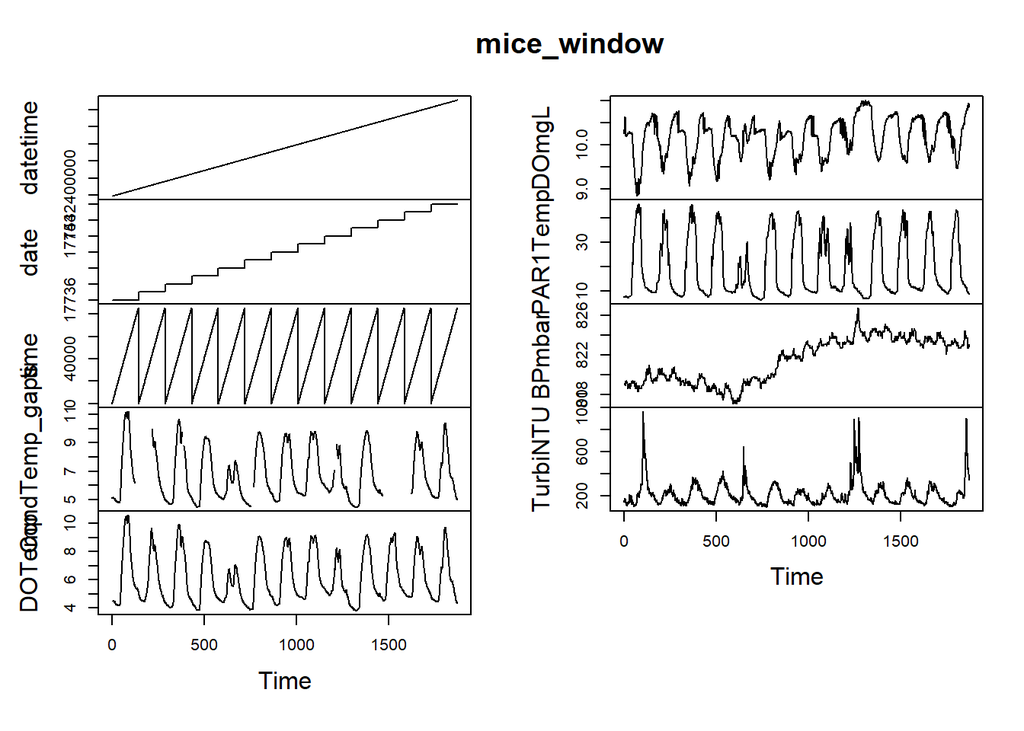

```r
plot.ts(mice_window)
```

Let’s now start with the gaps diagnosis of the stream water temperature TS.

1st. Visual diagnosis:

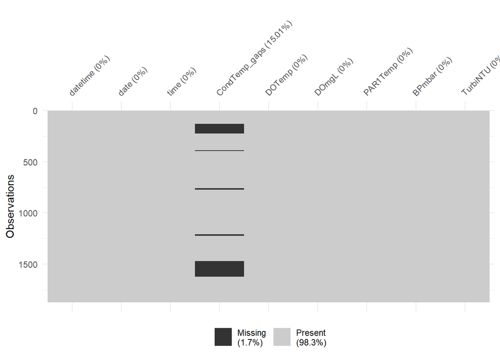

```r
vis_miss(mice_window)
```

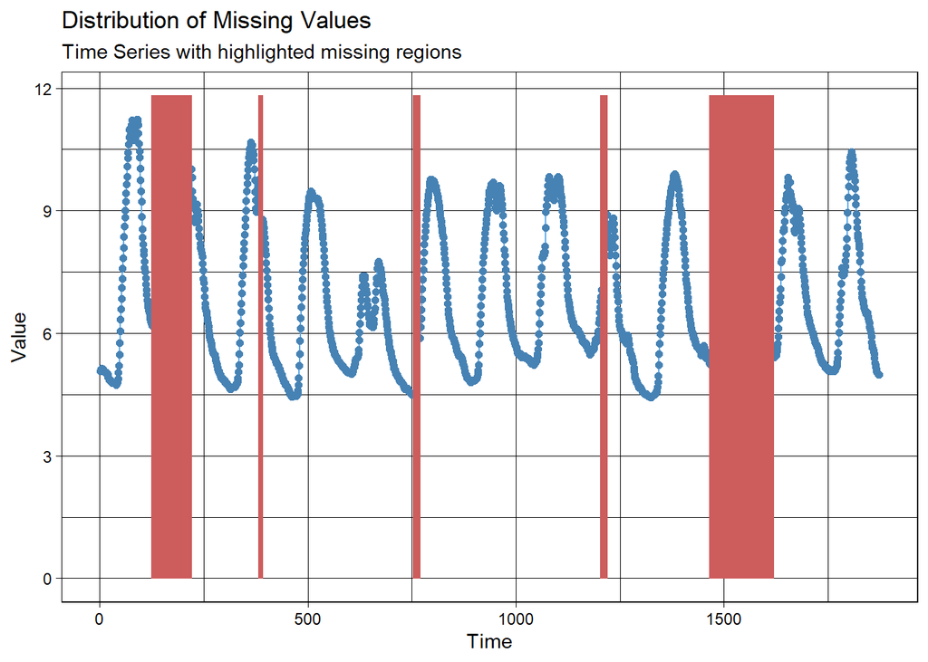

```r
ggplot_na_distribution(mice_window$CondTemp_gaps)
```

2nd. Data statistics:

```r
statsNA(mice_window$CondTemp_gaps)
```

```
## [1] "Length of time series:"
## [1] 1872
## [1] "-------------------------"
## [1] "Number of Missing Values:"
## [1] 281
## [1] "-------------------------"
## [1] "Percentage of Missing Values:"
## [1] "15%"
## [1] "-------------------------"
## [1] "Number of Gaps:"
## [1] 5
## [1] "-------------------------"
## [1] "Average Gap Size:"
## [1] 56.2
## [1] "-------------------------"
```

[output cut: 21 more lines]

```r
miss_mice_summary<- miss_var_summary(mice_window)
```

## 2. Simple imputation methods for univariate TS datasets

One of the key steps in data imputation is to select a “suitable” imputation method. So for instance, it is crystal clear that there is not need for a complex round of computations if there is only one gap in a 200 years TS. You will basically apply a simple interpolation (e.g., linear interpolation). In this subsection we will describe “simple approaches” that aim to solve “simple gap issues”.

### 2.1. Missing Value Imputation by Interpolation

Uses either linear, spline or stineman interpolation to replace missing values.

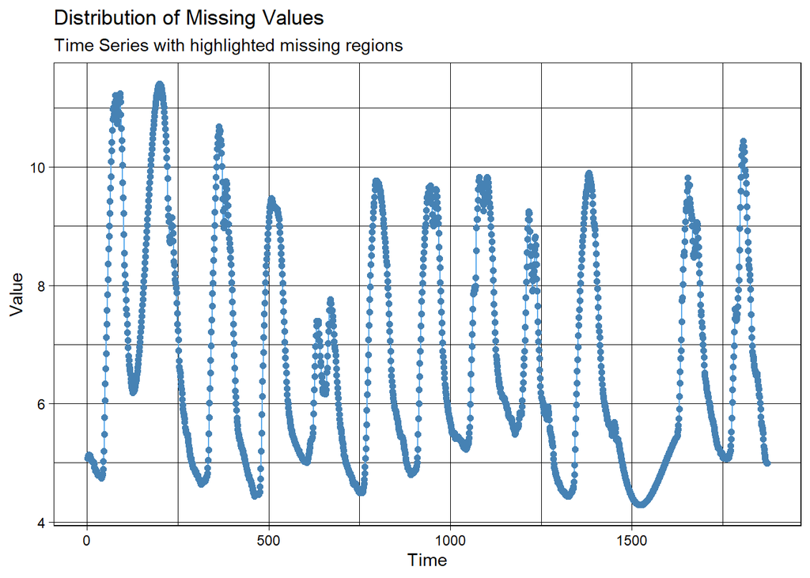

```r
mice_temp_interpolated <- mice_window$CondTemp_gaps%>%
                          na_interpolation(option = "spline")
ggplot_na_distribution(mice_temp_interpolated)
```

### 2.2. Missing Value Imputation by Weighted Moving Average

Missing value replacement by weighted moving average. Uses semi-adaptive window size to ensure all NAs are replaced.

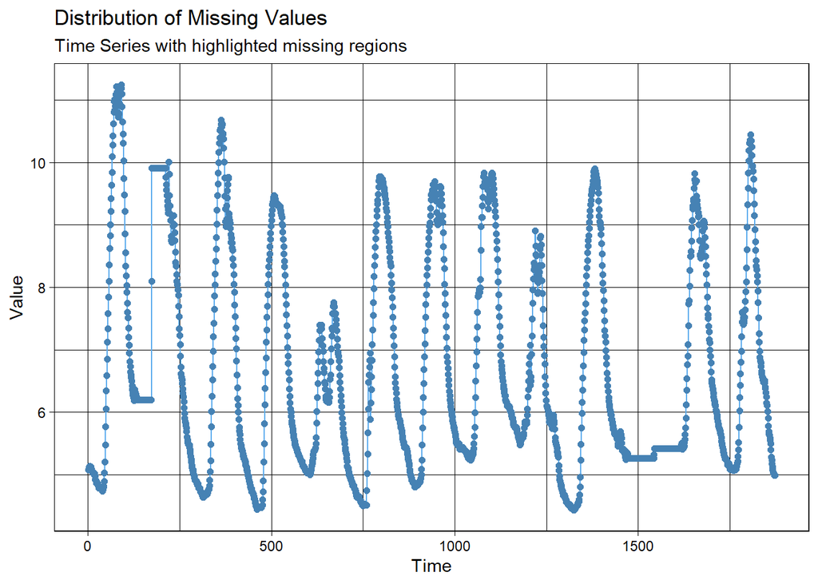

```r
mice_temp_ma <- mice_window$CondTemp_gaps%>%
                                         na_ma(k=10,
                                         weighting = "simple")
ggplot_na_distribution(mice_temp_ma)
```

### 2.3. Missing Value Imputation by Last Observation Carried Forward

Replaces each missing value with the most recent present value prior to it (Last Observation Carried Forward- LOCF).

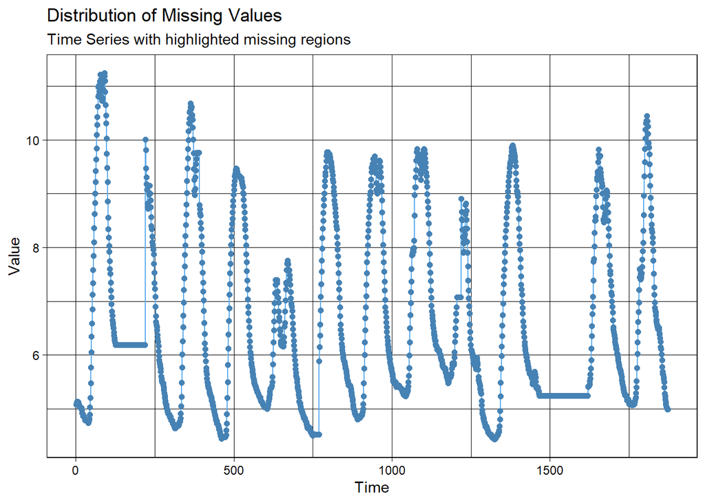

```r
mice_temp_locf <- mice_window$CondTemp_gaps%>%
                          na_locf(option = "locf")
ggplot_na_distribution(mice_temp_locf)
```

### 2.4. Other useful actions

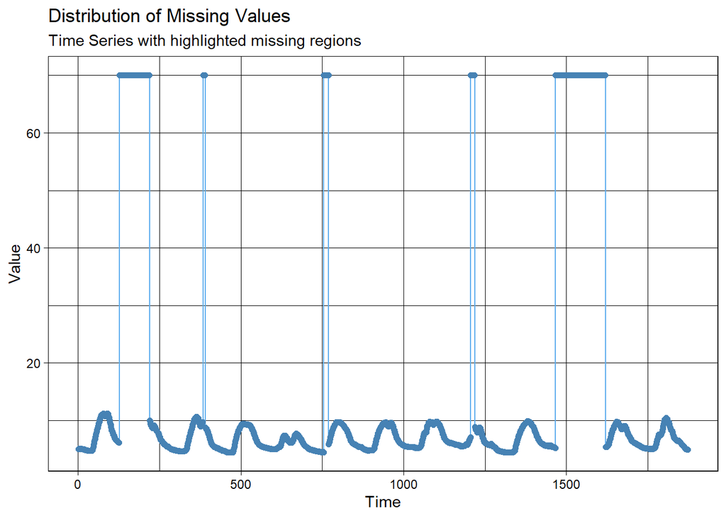

```r
mice_temp_replaced<- mice_window$CondTemp_gaps%>%
                     na_replace(fill = 70)
ggplot_na_distribution(mice_temp_replaced)
```

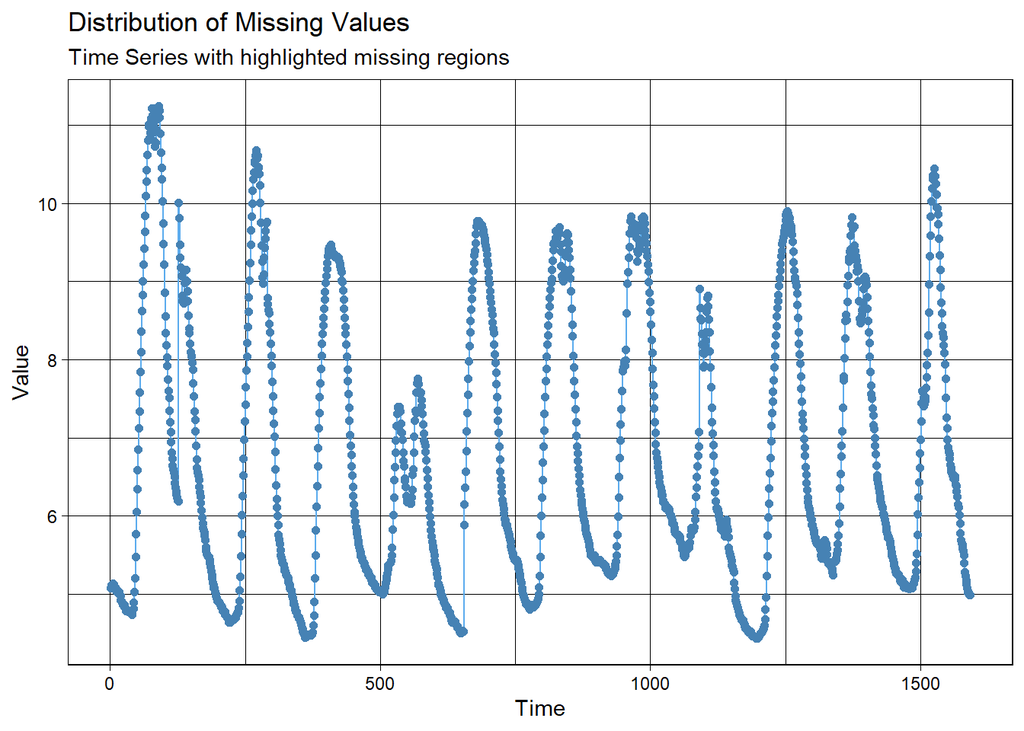

```r
mice_temp_remove <- mice_window$CondTemp_gaps%>%
                          na_remove()
ggplot_na_distribution(mice_temp_remove)
```

Be aware that the TS gets obviously shorter!

## 3. Advanced imputation methods for univariate and multivariate TS datasets

In this section we will focus in a specific imputation tool that uses both Multiple Imputation by Chained Equations (MICE) with a random forests machine learning algorithm. Machine learning comprises a group of computational algorithms that can perform pattern recognition, classification, and prediction on data by learning from existing data (training set).

For more information check out the`miceRanger` resources section.

### 3.1. Perform gap filling on “ONE variable” using miceRanger

```r
seqTime <- system.time(
  miceObj_m3_iter_5<- miceRanger(
    mice_window
    , m=3
    , maxiter = 5
    , returnModels = TRUE
    , verbose=TRUE
  )
)
```

```
##
## Process started at 2022-04-04 20:44:48
##
## dataset 1
## iteration 1   | CondTemp_gaps
## iteration 2   | CondTemp_gaps
## iteration 3   | CondTemp_gaps
## iteration 4   | CondTemp_gaps
## iteration 5   | CondTemp_gaps
##
## dataset 2
## iteration 1   | CondTemp_gaps
## iteration 2   | CondTemp_gaps
## iteration 3   | CondTemp_gaps
## iteration 4   | CondTemp_gaps
## iteration 5   | CondTemp_gaps
##
## dataset 3
## iteration 1   | CondTemp_gaps
## iteration 2   | CondTemp_gaps
## iteration 3   | CondTemp_gaps
## iteration 4   | CondTemp_gaps
## iteration 5   | CondTemp_gaps
```

Let’s check the how it went (data imputation diagnosis tools):

1. plotModelError

Random Forests give us a cheap way to determine model error without cross validation. Each model returns the OOB accuracy for classification, and r-squared for regression. We can see how these converged as the iterations progress:

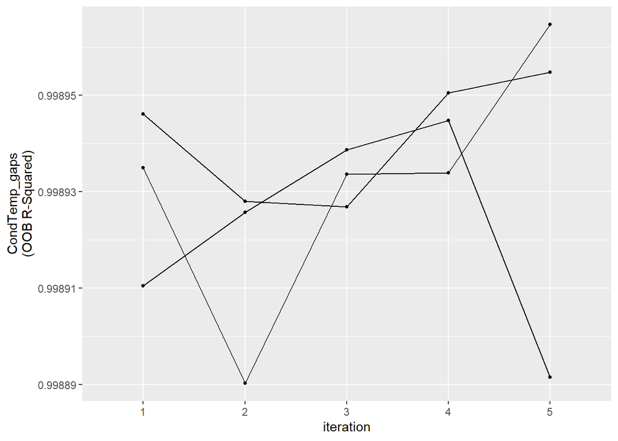

```r
plotModelError(miceObj_m3_iter_5,vars='allNumeric')
```

2. plotDistributions

Shows the distribution of the original data and the distribution of the imputed data. The gap filling went OK

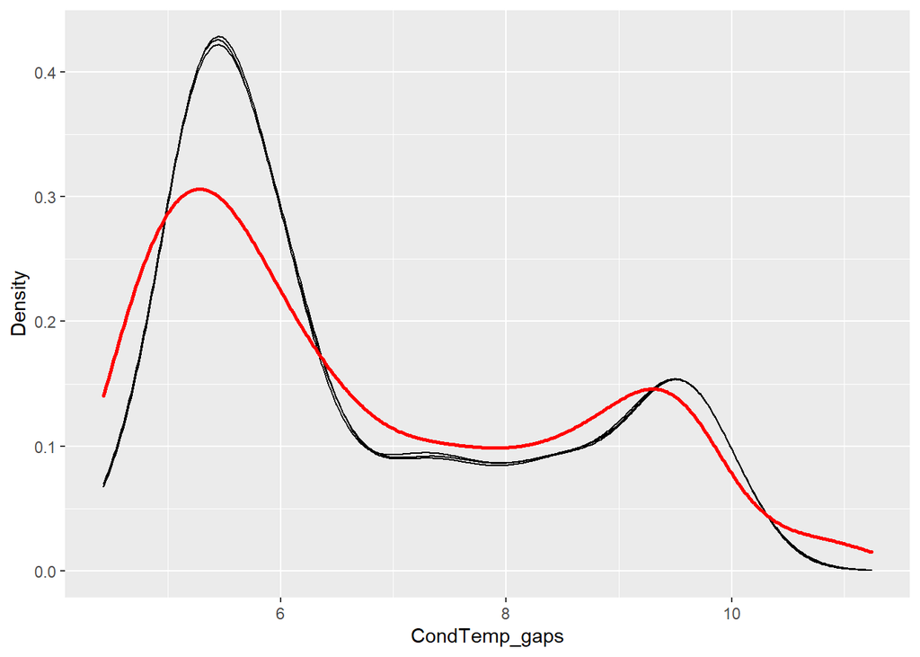

```r
plotDistributions(miceObj_m3_iter_5)
```

The red line is the density of the original, nonmissing data. The smaller, black lines are the density of the imputed values in each of the datasets. If these don’t match up, it’s not a problem, however it may tell you that your data was not Missing Completely at Random (MCAR).

3. plotVarImportance

Now let’s plot the variable importance for each imputed variable. The top axis contains the variable that was used to impute the variable on the left axis.

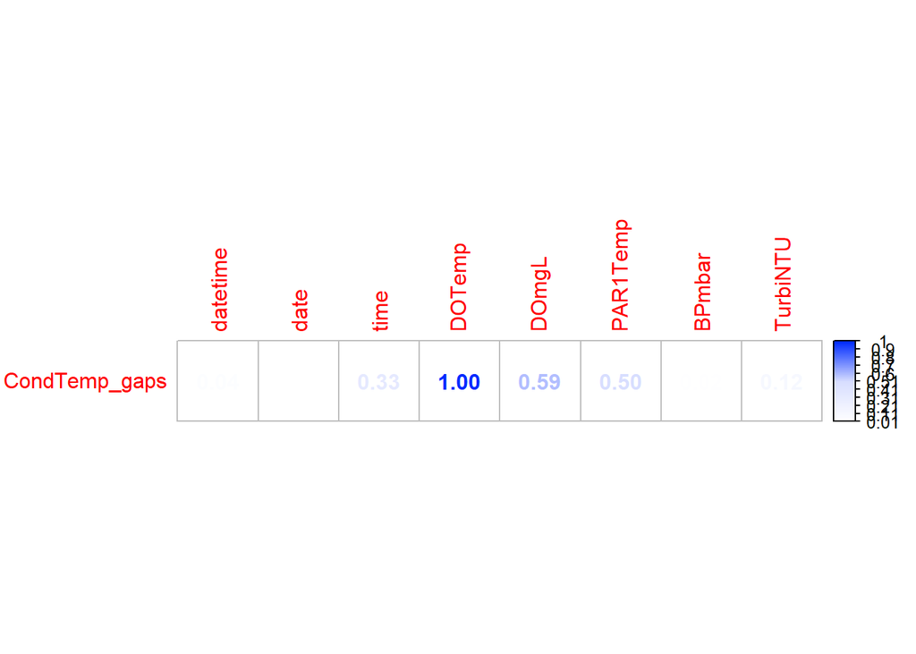

```r
plotVarImportance(miceObj_m3_iter_5)
```

List imputed datasets:

```r
dataList <- completeData(miceObj_m3_iter_5)
ds1 <- dataList[[1]]
ds2 <- dataList[[2]]
ds3 <- dataList[[3]]
```

Visualization of time series with (Measured data) and without (Imputed data) gaps:

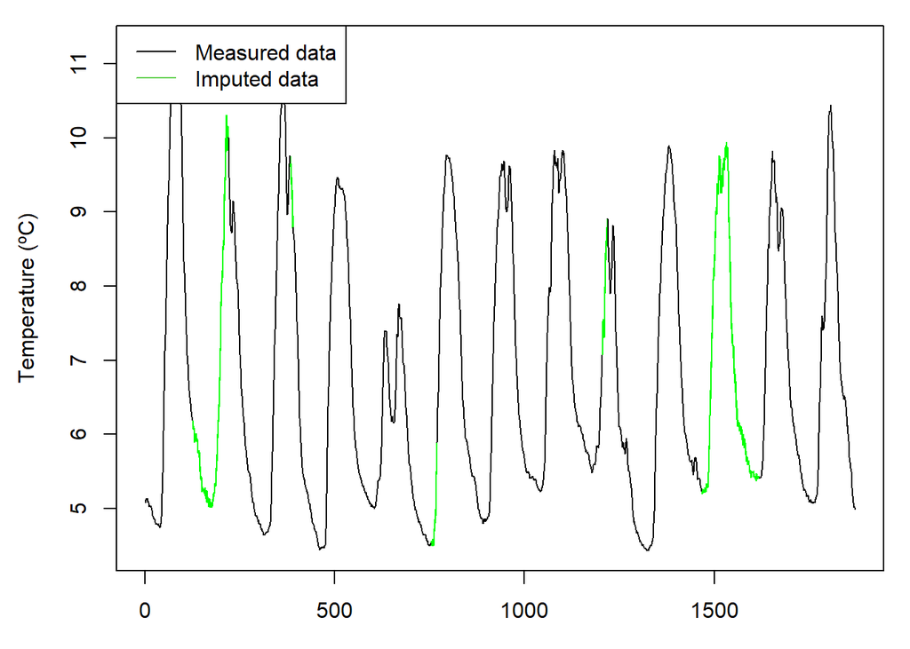

```r
par(mfrow= c(1,1), mar = c(3,4.5,1,1))
plot(ds1$CondTemp_gaps, type="l", col ="green",
     xlab = "Time", ylab = "Temperature (ºC)")
lines(ds2$CondTemp_gaps, type="l", col="green")
lines(ds3$CondTemp_gaps, type="l", col="green")
lines(mice_window$CondTemp_gaps, type="l", col=1)
legend("topleft", c("Measured data", "Imputed data"), lty =1, col = c(1,3))
```

### 3.2. Perform gap filling on “ONE variable” using miceRanger (lets challange the model performance)

1st. Let’s make more gaps into the response variable TS

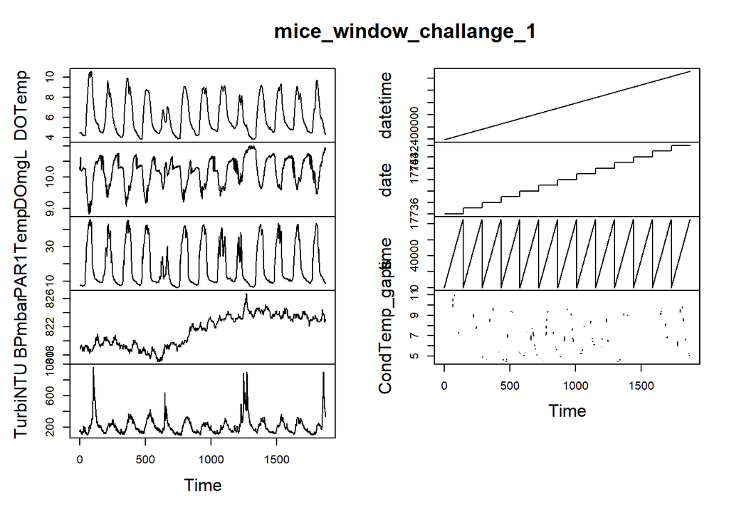

```r
mice_window_challange_1 <- amputeData(mice_window[,4],perc=0.75)
mice_window_challange_1 <- cbind(mice_window[,1:3],mice_window_challange_1)
mice_window_challange_1 <- cbind(mice_window[,5:9],mice_window_challange_1)

plot.ts(mice_window_challange_1)
```

2nd. Let’s remove an IMPORTANT VARIABLES acording with the Variable Importance graph

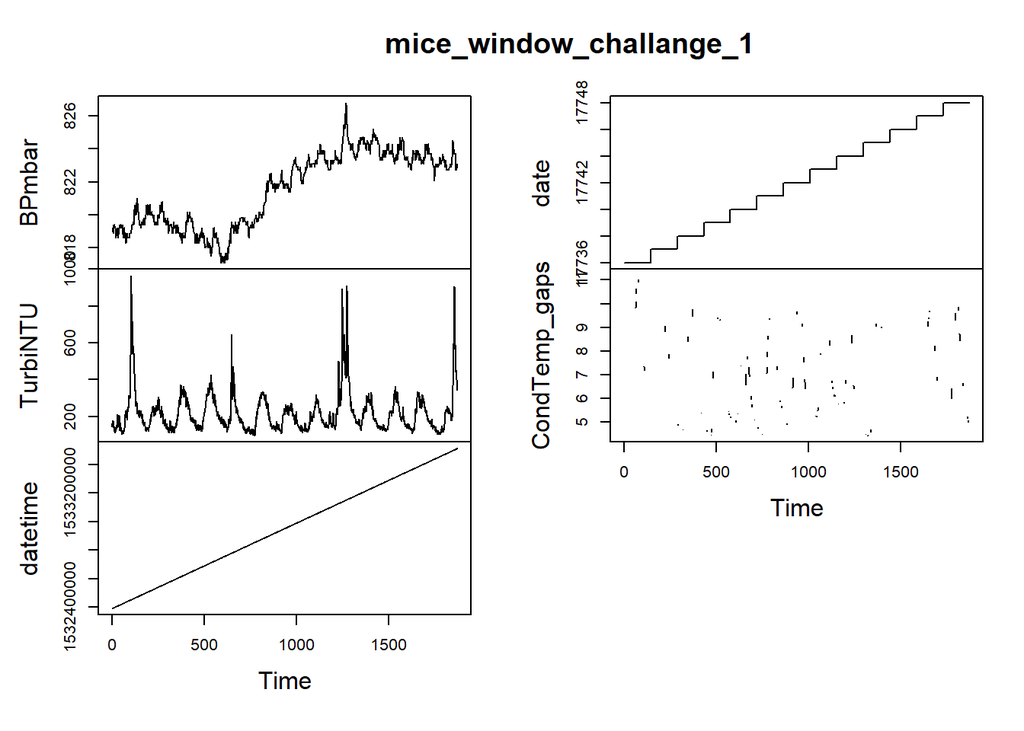

```r
mice_window_challange_1<- mice_window_challange_1 %>% select (-c(DOTemp, DOmgL,PAR1Temp, time))

plot.ts(mice_window_challange_1)
```

Let’s run miceRanger again:

```r
seqTime <- system.time(
  miceObj_m3_iter_5<- miceRanger(
    mice_window_challange_1
    , m=3
    , maxiter = 5
    , returnModels = TRUE
    , verbose=TRUE
  )
)
```

```
##
## Process started at 2022-04-04 20:45:00
##
## dataset 1
## iteration 1   | CondTemp_gaps
## iteration 2   | CondTemp_gaps
## iteration 3   | CondTemp_gaps
## iteration 4   | CondTemp_gaps
## iteration 5   | CondTemp_gaps
##
## dataset 2
## iteration 1   | CondTemp_gaps
## iteration 2   | CondTemp_gaps
## iteration 3   | CondTemp_gaps
## iteration 4   | CondTemp_gaps
## iteration 5   | CondTemp_gaps
##
## dataset 3
## iteration 1   | CondTemp_gaps
## iteration 2   | CondTemp_gaps
## iteration 3   | CondTemp_gaps
## iteration 4   | CondTemp_gaps
## iteration 5   | CondTemp_gaps
```

Let’s check the how it went (data imputation diagnosis tools):

1. plotModelError

Random Forests give us a cheap way to determine model error without cross validation. Each model returns the OOB accuracy for classification, and r-squared for regression. We can see how these converged as the iterations progress:

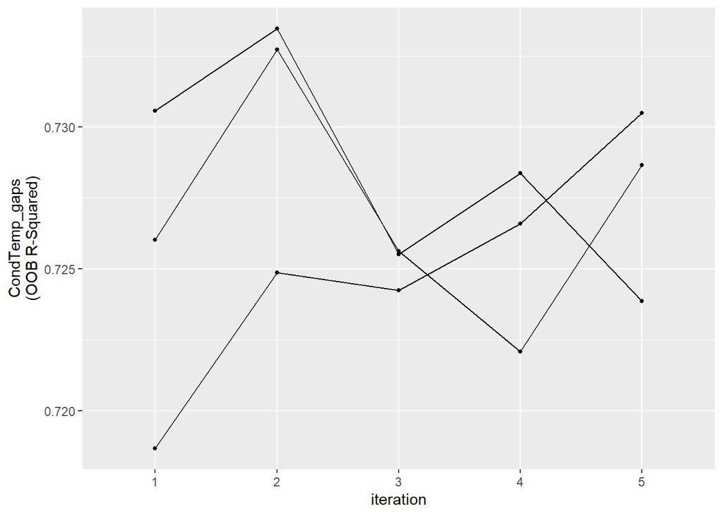

```r
plotModelError(miceObj_m3_iter_5,vars='allNumeric')
```

2. plotDistributions

Shows the distribution of the original data and the distribution of the imputed data. The gap filling went OK

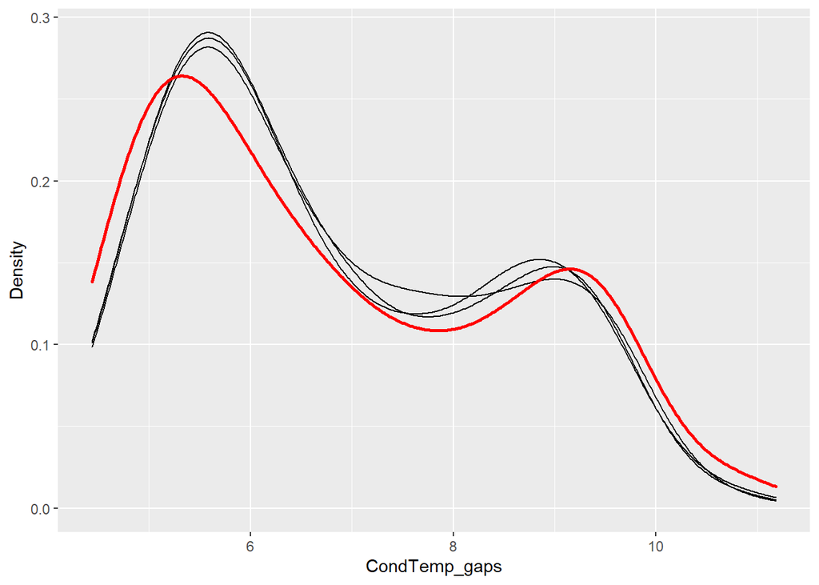

```r
plotDistributions(miceObj_m3_iter_5)
```

The red line is the density of the original, nonmissing data. The smaller, black lines are the density of the imputed values in each of the datasets. If these don’t match up, it’s not a problem, however it may tell you that your data was not Missing Completely at Random (MCAR).

3. plotVarImportance

Now let’s plot the variable importance for each imputed variable. The top axis contains the variable that was used to impute the variable on the left axis.

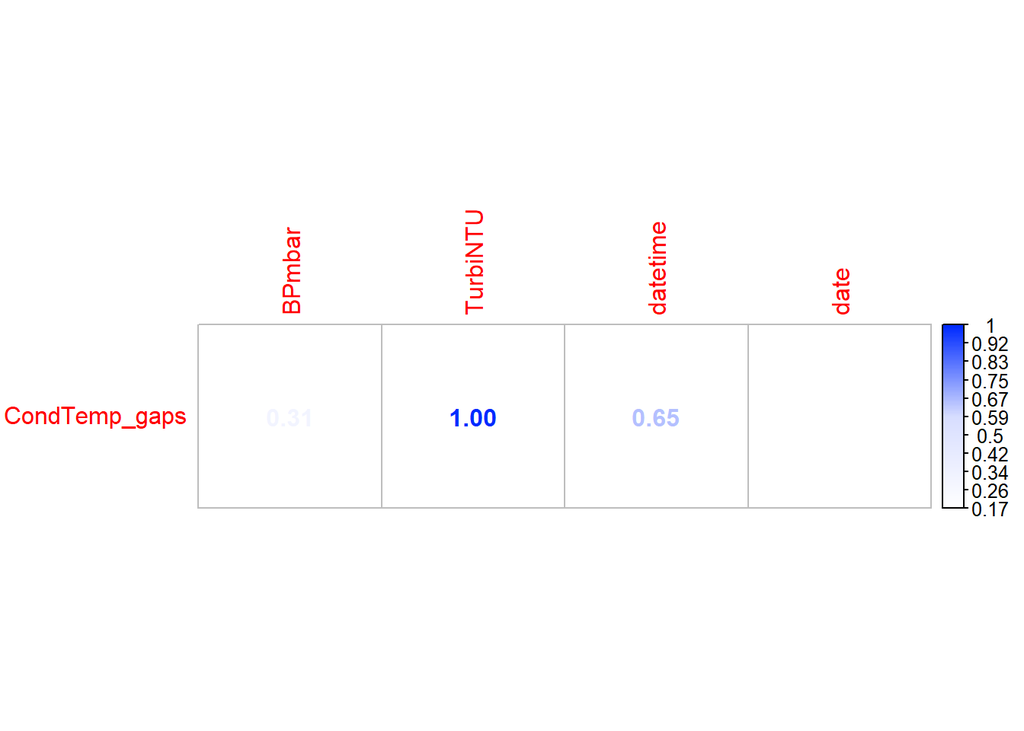

```r
plotVarImportance(miceObj_m3_iter_5)
```

List imputed datasets:

```r
dataList <- completeData(miceObj_m3_iter_5)
ds1 <- dataList[[1]]
ds2 <- dataList[[2]]
ds3 <- dataList[[3]]
```

Visualization of time series with (Measured data) and without (Imputed data) gaps:

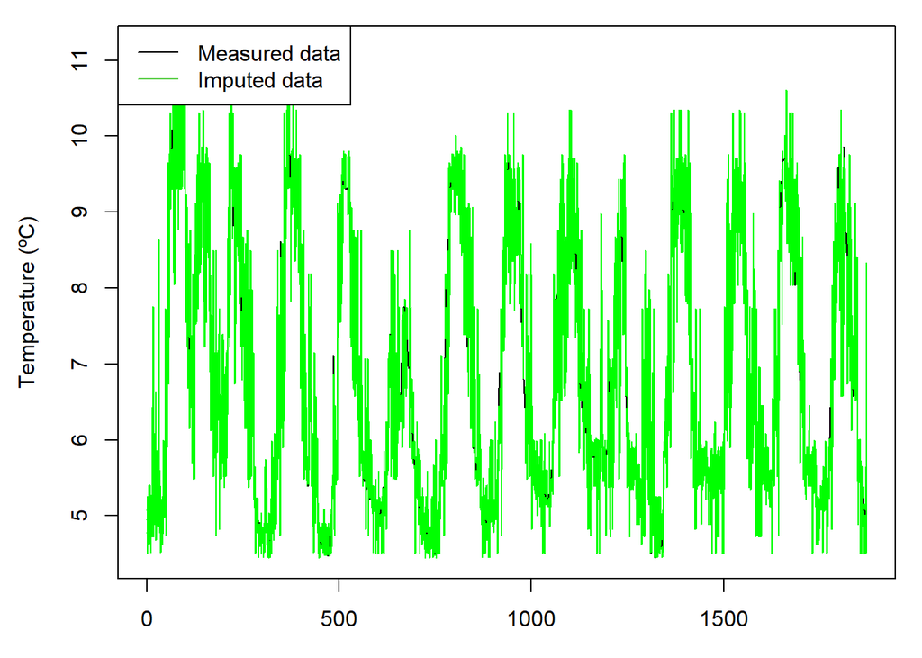

```r
par(mfrow= c(1,1), mar = c(3,4.5,1,1))
plot(ds1$CondTemp_gaps, type="l", col ="green",
     xlab = "Time", ylab = "Temperature (ºC)")
lines(ds2$CondTemp_gaps, type="l", col="green")
lines(ds3$CondTemp_gaps, type="l", col="green")
lines(mice_window_challange_1$CondTemp_gaps, type="l", col=1)
legend("topleft", c("Measured data", "Imputed data"), lty =1, col = c(1,3))
```

### 3.3. Perform gap filling on “MULTIPLE variable” using miceRanger

Let’s first make the gaps into all the variables of the TS

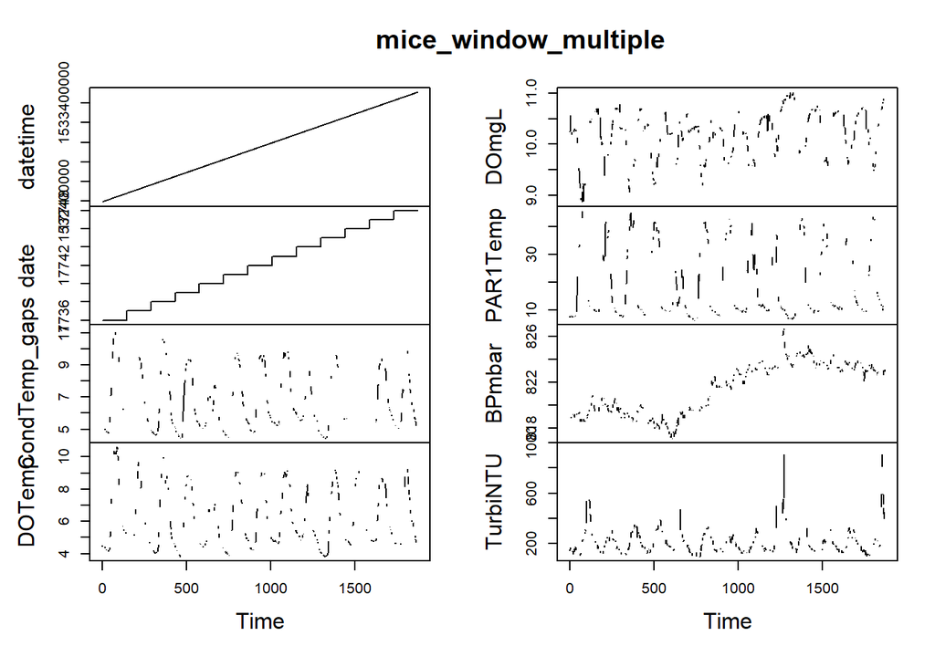

```r
mice_window_multiple <- amputeData(mice_window[,4:9],perc=0.6)
mice_window_multiple <- cbind(mice_window[,1:2],mice_window_multiple)

plot.ts(mice_window_multiple)
```

Let’s remove date and time to evaluate how important are for the models.

```r
#mice_window_multiple<- mice_window_multiple %>% select (-c(datetime,date))

#plot.ts(mice_window_multiple)
```

Let’s run miceRanger again:

```r
seqTime <- system.time(
  miceObj_m3_iter_5<- miceRanger(
    mice_window_multiple
    , m=3
    , maxiter = 5
    , returnModels = TRUE
    , verbose=TRUE
  )
)
```

```
##
## Process started at 2022-04-04 20:45:06
##
## dataset 1
## iteration 1   | CondTemp_gaps | DOTemp | DOmgL | PAR1Temp | BPmbar | TurbiNTU
## iteration 2   | CondTemp_gaps | DOTemp | DOmgL | PAR1Temp | BPmbar | TurbiNTU
## iteration 3   | CondTemp_gaps | DOTemp | DOmgL | PAR1Temp | BPmbar | TurbiNTU
## iteration 4   | CondTemp_gaps | DOTemp | DOmgL | PAR1Temp | BPmbar | TurbiNTU
## iteration 5   | CondTemp_gaps | DOTemp | DOmgL | PAR1Temp | BPmbar | TurbiNTU
##
## dataset 2
## iteration 1   | CondTemp_gaps | DOTemp | DOmgL | PAR1Temp | BPmbar | TurbiNTU
## iteration 2   | CondTemp_gaps | DOTemp | DOmgL | PAR1Temp | BPmbar | TurbiNTU
## iteration 3   | CondTemp_gaps | DOTemp | DOmgL | PAR1Temp | BPmbar | TurbiNTU
## iteration 4   | CondTemp_gaps | DOTemp | DOmgL | PAR1Temp | BPmbar | TurbiNTU
## iteration 5   | CondTemp_gaps | DOTemp | DOmgL | PAR1Temp | BPmbar | TurbiNTU
##
## dataset 3
## iteration 1   | CondTemp_gaps | DOTemp | DOmgL | PAR1Temp | BPmbar | TurbiNTU
## iteration 2   | CondTemp_gaps | DOTemp | DOmgL | PAR1Temp | BPmbar | TurbiNTU
## iteration 3   | CondTemp_gaps | DOTemp | DOmgL | PAR1Temp | BPmbar | TurbiNTU
## iteration 4   | CondTemp_gaps | DOTemp | DOmgL | PAR1Temp | BPmbar | TurbiNTU
## iteration 5   | CondTemp_gaps | DOTemp | DOmgL | PAR1Temp | BPmbar | TurbiNTU
```

Let’s check the how it went (data imputation diagnosis tools):

1. plotModelError

Random Forests give us a cheap way to determine model error without cross validation. Each model returns the OOB accuracy for classification, and r-squared for regression. We can see how these converged as the iterations progress:

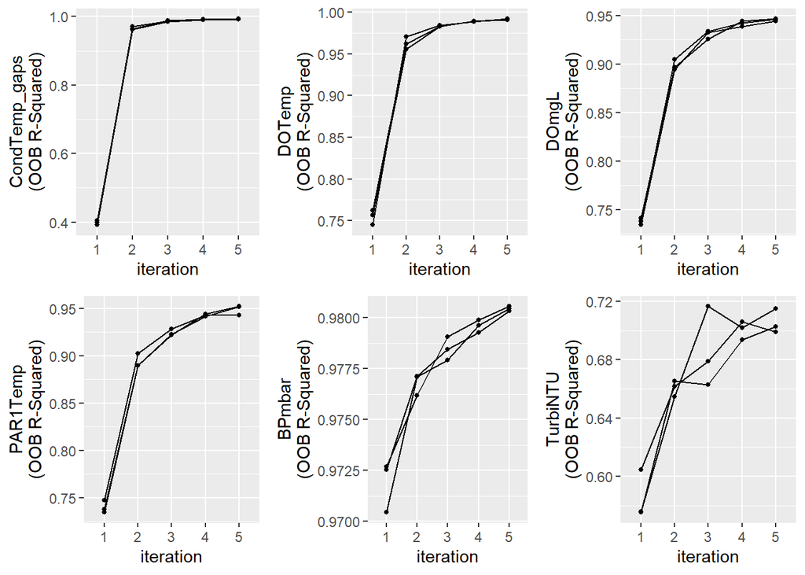

```r
plotModelError(miceObj_m3_iter_5,vars='allNumeric')
```

2. plotDistributions

Shows the distribution of the original data and the distribution of the imputed data. The gap filling went OK

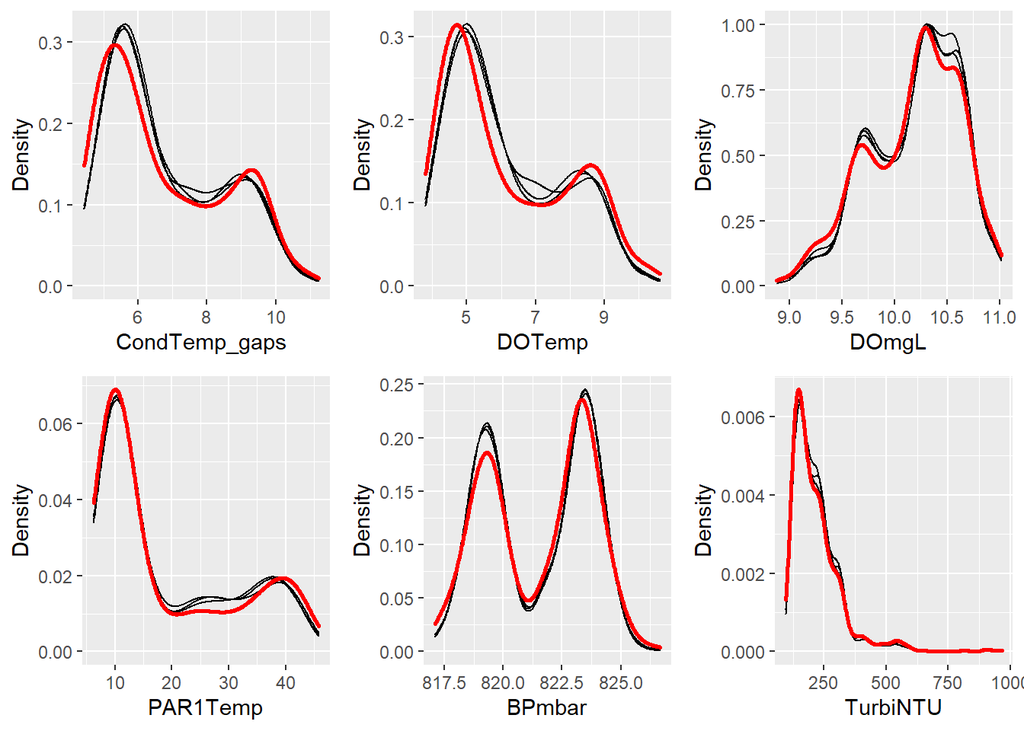

```r
plotDistributions(miceObj_m3_iter_5)
```

The red line is the density of the original, nonmissing data. The smaller, black lines are the density of the imputed values in each of the datasets. If these don’t match up, it’s not a problem, however it may tell you that your data was not Missing Completely at Random (MCAR).

3. plotVarImportance

Now let’s plot the variable importance for each imputed variable. The top axis contains the variable that was used to impute the variable on the left axis.

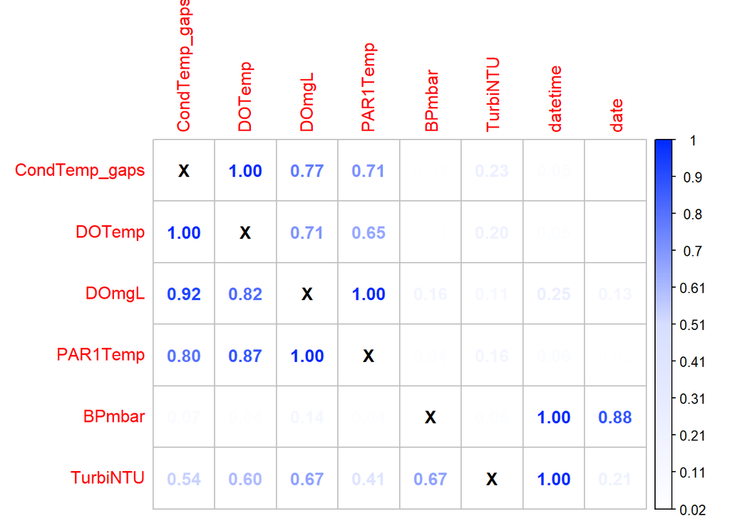

```r
plotVarImportance(miceObj_m3_iter_5)
```

List imputed datasets:

```r
dataList <- completeData(miceObj_m3_iter_5)
ds1 <- dataList[[1]]
ds2 <- dataList[[2]]
ds3 <- dataList[[3]]
```

Visualization of time series with (Measured data) and without (Imputed data) gaps:

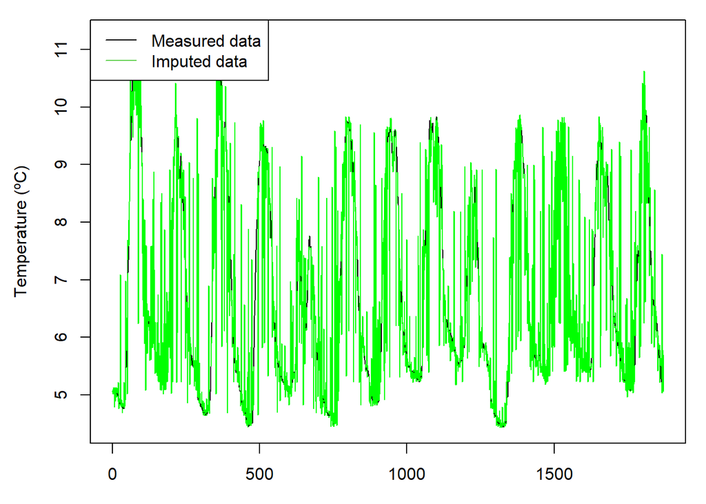

```r
par(mfrow= c(1,1), mar = c(3,4.5,1,1))
plot(ds1$CondTemp_gaps, type="l", col ="green",
     xlab = "Time", ylab = "Temperature (ºC)")
lines(ds2$CondTemp_gaps, type="l", col="green")
lines(ds3$CondTemp_gaps, type="l", col="green")
lines(mice_window_multiple$CondTemp_gaps, type="l", col=1)
legend("topleft", c("Measured data", "Imputed data"), lty =1, col = c(1,3))
```

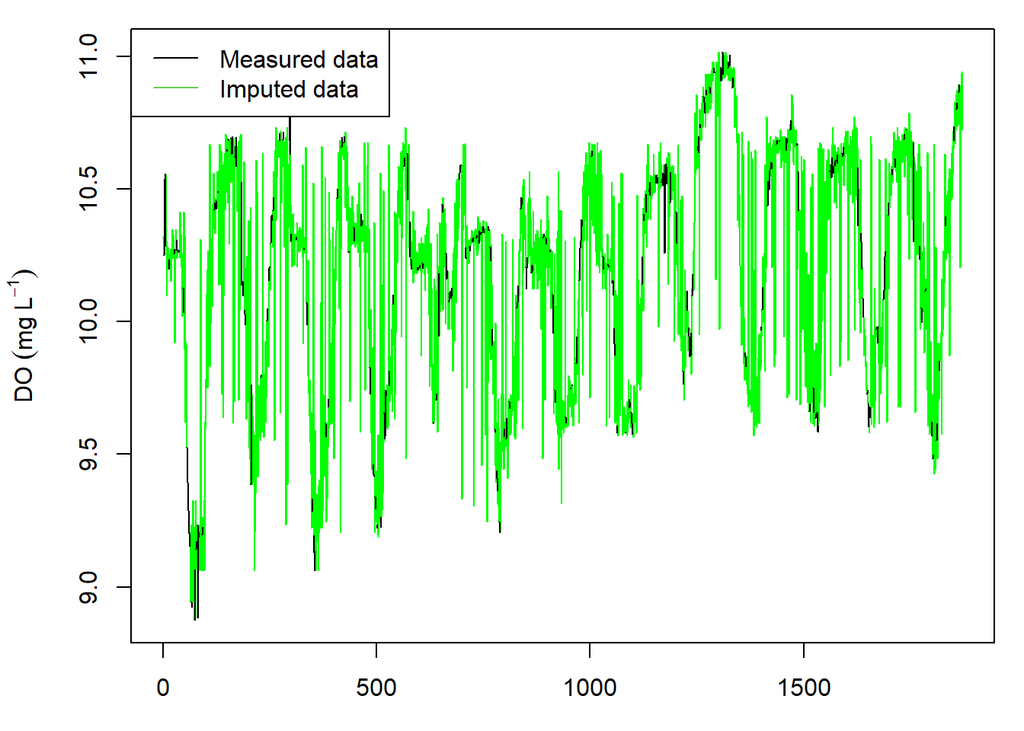

```r
par(mfrow= c(1,1), mar = c(3,4.5,1,1))
plot(ds1$DOmgL, type="l", col ="green",
     xlab = "Time", ylab = expression(paste(DO~(mg~L^-1))))
lines(ds2$DOmgL, type="l", col="green")
lines(ds3$DOmgL, type="l", col="green")
lines(mice_window_multiple$DOmgL, type="l", col=1)
legend("topleft", c("Measured data", "Imputed data"), lty =1, col = c(1,3))
```

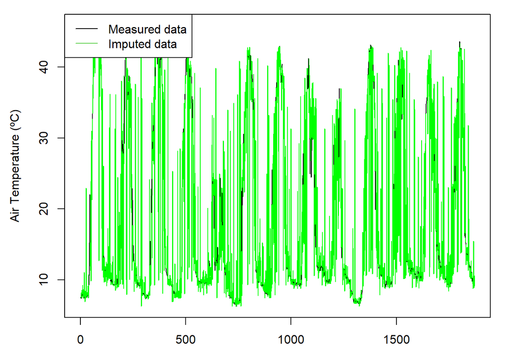

```r
par(mfrow= c(1,1), mar = c(3,4.5,1,1))
plot(ds1$PAR1Temp, type="l", col ="green",
     xlab = "Time", ylab = "Air Temperature (ºC)")
lines(ds2$PAR1Temp, type="l", col="green")
lines(ds3$PAR1Temp, type="l", col="green")
lines(mice_window_multiple$PAR1Temp, type="l", col=1)
legend("topleft", c("Measured data", "Imputed data"), lty =1, col = c(1,3))
```

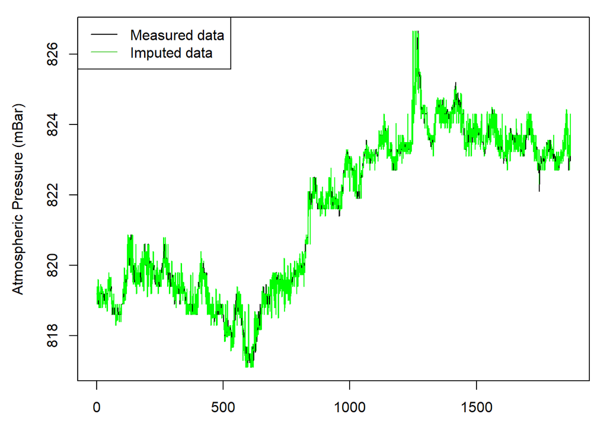

```r
par(mfrow= c(1,1), mar = c(3,4.5,1,1))
plot(ds1$BPmbar, type="l", col ="green",
     xlab = "Time", ylab = "Atmospheric Pressure (mBar)")
lines(ds2$BPmbar, type="l", col="green")
lines(ds3$BPmbar, type="l", col="green")
lines(mice_window_multiple$BPmbar, type="l", col=1)
legend("topleft", c("Measured data", "Imputed data"), lty =1, col = c(1,3))
```

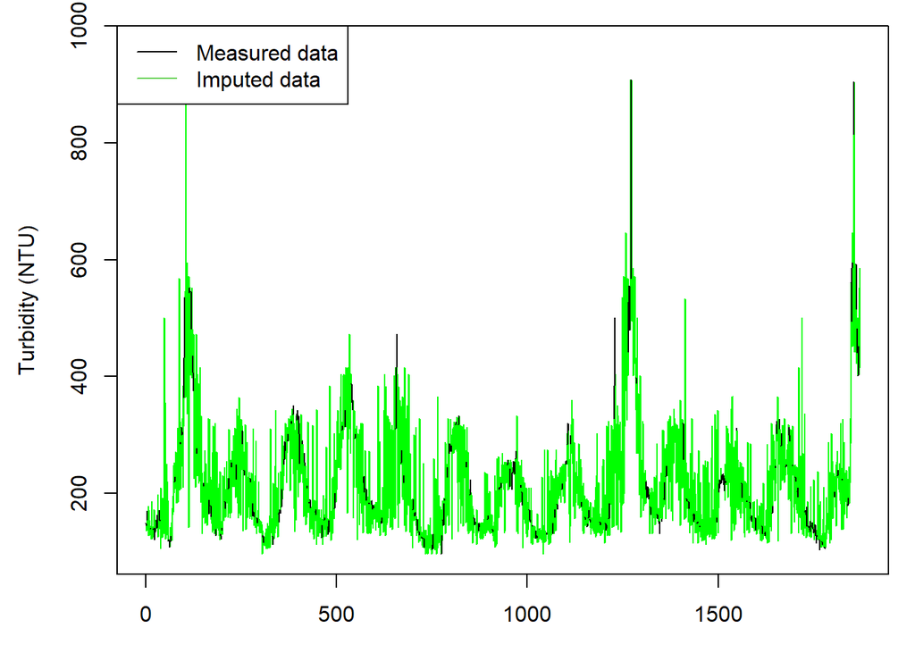

```r
par(mfrow= c(1,1), mar = c(3,4.5,1,1))
plot(ds1$TurbiNTU, type="l", col ="green",
     xlab = "Time", ylab = "Turbidity (NTU)")
lines(ds2$TurbiNTU, type="l", col="green")
lines(ds3$TurbiNTU, type="l", col="green")
lines(mice_window_multiple$TurbiNTU, type="l", col=1)
legend("topleft", c("Measured data", "Imputed data"), lty =1, col = c(1,3))
```

# Exercise 1: Snow cover - Data imputation

Let’s first read the .csv file need it for the exercise, for this we will use the function `read_csv()`, which is part of the core `tidyverse`.

```r
snow_pyr <- read_csv('00_course datasets/snow_pyrenees_gaps.csv')
```

In this exercise we will focus in the long-term TS of snow cover in the Pyrenees obtained by the Moderate Resolution Imaging Spectroradiometer (MODIS) instrument. For a more detailed description of the methods see:[Website](https://zenodo.org/record/162299#.YkgWtyjP02w). Additionally, the updated data is visible here: [Website](https://labo.obs-mip.fr/multitemp/pyrenees-snow-monitor/).

Let’s have a look how this TS looks like:

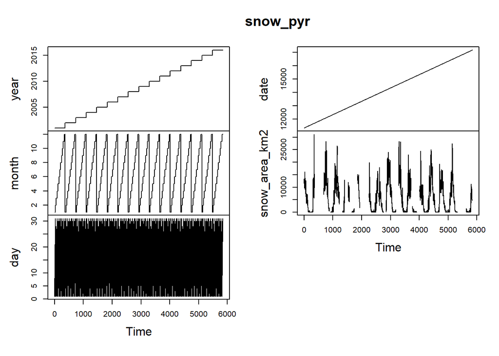

```r
plot.ts(snow_pyr)
```

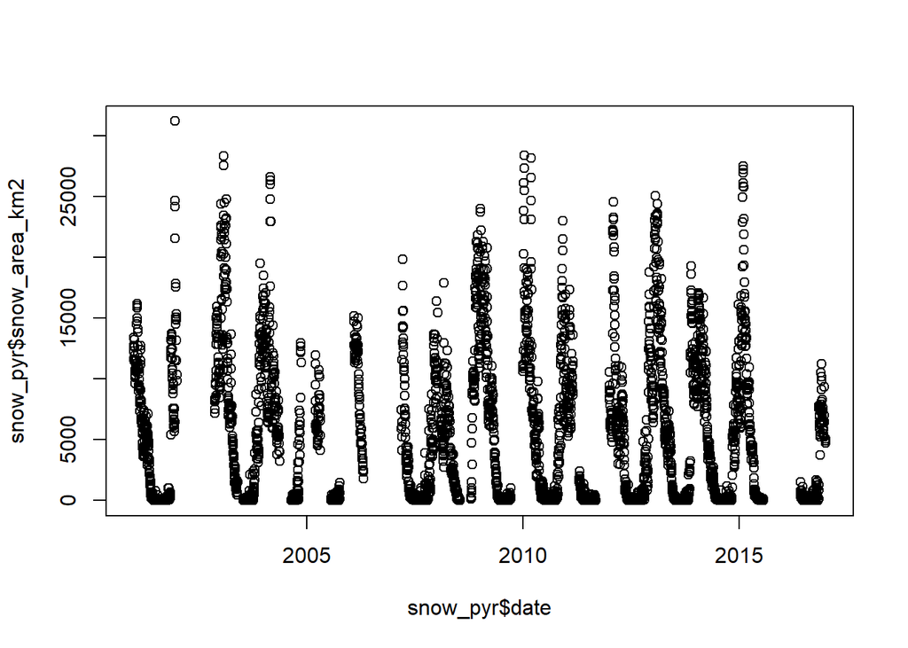

```r
plot(snow_pyr$date,snow_pyr$snow_area_km2)
```

## Question 1: Describe numerically (with a short statistical report) and visually how is the gap structure in the snow area variable of the TS.

1st. Visual diagnosis:

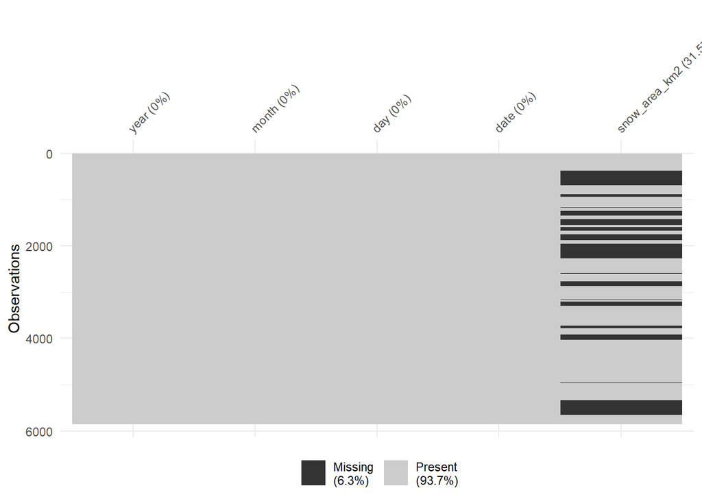

```r
vis_miss(snow_pyr)
```

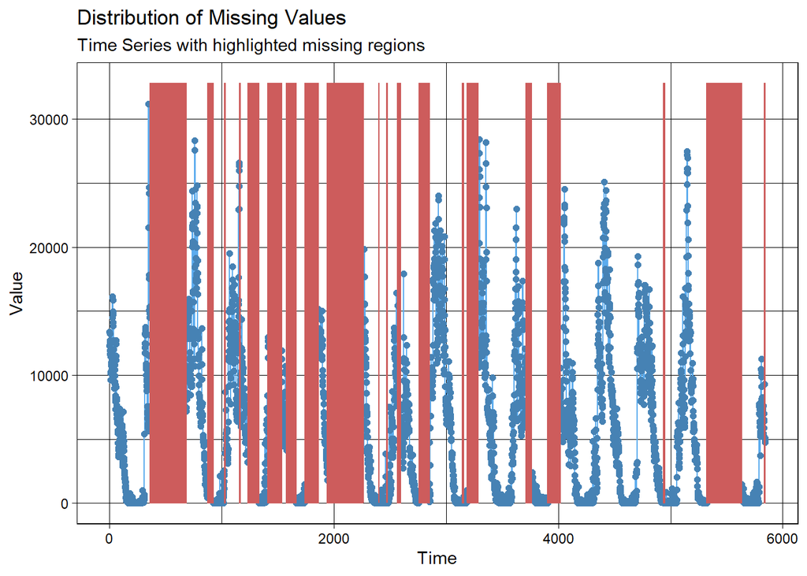

```r
ggplot_na_distribution(snow_pyr$snow_area_km2)
```

2nd. Data statistics:

```r
statsNA(snow_pyr$snow_area_km2)
```

```
## [1] "Length of time series:"
## [1] 5844
## [1] "-------------------------"
## [1] "Number of Missing Values:"
## [1] 1845
## [1] "-------------------------"
## [1] "Percentage of Missing Values:"
## [1] "31.6%"
## [1] "-------------------------"
## [1] "Number of Gaps:"
## [1] 20
## [1] "-------------------------"
## [1] "Average Gap Size:"
## [1] 92.25
## [1] "-------------------------"
```

[output cut: 33 more lines]

```r
miss_summary<- miss_var_summary(snow_pyr)
```